# Colocation data

## Links to local data sets

Here we use the following links to data.

```r
census_path <- "~/Dropbox/aaa/studies/oucomo/clean data/census2019.rds"
colocation_path <- "~/Dropbox/aaa/studies/data for good/data/geoinsights/colocation maps/"
```

Change them accordingly if you want to run the script locally on your computer.

## Preambule

This document shows how to combine 3 data sets:

- the colocation dataset from the Facebook’s [Data for Good](https://dataforgood.fb.com) initiative;
- the geographical polygons from [GADM](https://gadm.org) (UC Davis);
- the 2019 population census data of Vietnam from [GSO](https://www.gso.gov.vn).

These three data sets provide information by district (roughly 700 in Vietnam). The difficulties come from the fact that these 3 datasets listed above do not have exactly the same districts definitions. Indeed, as the population grows with time, districts tend to split. The problems we had to deal with here are

- one province and a few other districts are missing from the 2019 census data. Missing value were completed by hand with data from [Wikipedia](https://en.wikipedia.org/wiki/Vĩnh_Long_Province#Administrative_divisions).
- the polygon of one district is missing from GADM. This was completed by hand with data from [OpenStreetMap](https://www.openstreetmap.org).
- the colocation dataset uses the district definition from [Bing](https://www.bing.com/maps) that dates from at least 10 years back, meaning that we have to merge a number of districts in both GADM and the census data in order to make them consistent with the definition used in the colocation data. In some cases, we had to split a district before merging the 2 parts to 2 different districts. In order to split the population accurately, we used also population density raster data from [WorldPop](https://www.worldpop.org) (University of Southampton).

## Packages

```r
library(sf)
library(stars)
library(osmdata)
library(magrittr)
library(stringr)
library(lubridate)
library(tidyr)
library(purrr)
library(dplyr) # best to load last
```

```r
hist2 <- function(...) hist(..., main = NA)
```

## Population density raster data

Downloading the population density data from [WorldPop](https://www.worldpop.org):

```r
download.file("ftp://ftp.worldpop.org.uk/GIS/Population/Individual_countries/VNM/Viet_Nam_100m_Population/VNM_ppp_v2b_2020_UNadj.tif",
              "VNM_ppp_v2b_2020_UNadj.tif")
```

Loading the data:

```r
worldpop <- read_stars("VNM_ppp_v2b_2020_UNadj.tif")
```

## Google and Apple mobility data

Downloading the population mobility data:

```r
download.file("https://www.dropbox.com/s/6fl62gcuma9890f/google.rds?raw=1", "google.rds")
download.file("https://www.dropbox.com/s/uuxxjm3cgs0a4gw/apple.rds?raw=1", "apple.rds")
```

Loading the data:

```r
google <- readRDS("google.rds")
apple <- readRDS("apple.rds") %>%
  mutate_if(is.numeric, subtract, 100)
```

## Polygons from GADM

Downloading the polygons from [GADM](https://gadm.org):

```r
download.file("https://biogeo.ucdavis.edu/data/gadm3.6/Rsf/gadm36_VNM_0_sf.rds", "gadm36_VNM_0_sf.rds")
download.file("https://biogeo.ucdavis.edu/data/gadm3.6/Rsf/gadm36_VNM_1_sf.rds", "gadm36_VNM_1_sf.rds")
download.file("https://biogeo.ucdavis.edu/data/gadm3.6/Rsf/gadm36_VNM_2_sf.rds", "gadm36_VNM_2_sf.rds")
download.file("https://biogeo.ucdavis.edu/data/gadm2.8/rds/VNM_adm2.rds"       , "VNM_adm2.rds")
download.file("https://biogeo.ucdavis.edu/data/gadm2.8/rds/VNM_adm3.rds"       , "VNM_adm3.rds")
```

Loading the polygons:

```r
vn0 <- readRDS("gadm36_VNM_0_sf.rds")     # country polygon
vn1 <- readRDS("gadm36_VNM_1_sf.rds")     # provinces polygons

vn2 <- readRDS("gadm36_VNM_2_sf.rds") %>% # districts polygons
  transmute(province = str_squish(NAME_1),
            district = str_squish(NAME_2) %>%
              str_remove_all("Thành Phố |Thị Xã |Quận "))

vn2_old <- readRDS("VNM_adm2.rds") %>%    # old version of the districts polygons
  st_as_sf() %>%
  transmute(province = str_squish(NAME_1),
            district = str_squish(NAME_2) %>%
              str_remove_all("Thành Phố |Thị Xã |Quận ") %>%
              str_replace("Chiêm Hoá", "Chiêm Hóa"))

vn3_old <- readRDS("VNM_adm3.rds") %>%    # old version of the communes polygons
  st_as_sf() %>%
  transmute(province = str_squish(NAME_1),
            district = str_squish(NAME_2) %>%
              str_remove_all("Thành Phố |Thị Xã |Quận ") %>%
              str_replace("Chiêm Hoá", "Chiêm Hóa"),
            commune = str_squish(NAME_3)) %>%
  arrange(province, district, commune)
```

Removing the commune Huæi Luông from the district Sìn Hồ:

```r
vn2_old %<>%
  filter(district == "Sìn Hồ") %>%
  st_set_geometry(st_union(filter(vn3_old, district == "Sìn Hồ", commune != "Huæi Luông"))) %>%
  rbind(filter(vn2_old, district != "Sìn Hồ")) %>%
  arrange(province, district)
```

## Adding the polygon for Côn Đảo from OpenStreetMap

Downloading the administrative boundaries from [OpenStreetMap](https://www.openstreetmap.org):

```r
con_dao <- c(106.523384, 8.622214, 106.748218, 8.782639) %>%
  opq() %>%
  add_osm_feature(key = "boundary", value = "administrative") %>%
  osmdata_sf()
```

```
## Request failed [502]. Retrying in 1.1 seconds...
```

```
## Request failed [504]. Retrying in 1.8 seconds...
```

The main island is made of lines. Let’s transform them into a polygon:

```r
main_island <- con_dao$osm_lines %>%
  st_combine() %>%
  st_polygonize() %>%
  st_geometry() %>%
  st_collection_extract("POLYGON")
```

The other islands are already polygons. Let’s extract and merge them with the newly created polygon of the main island:

```r
con_dao <- con_dao$osm_polygons %>%
  st_geometry() %>%
  c(main_island) %>%
  st_multipolygon() %>%
  st_sfc(crs = st_crs(vn2))
```

Here are the polygons for Côn Đảo:

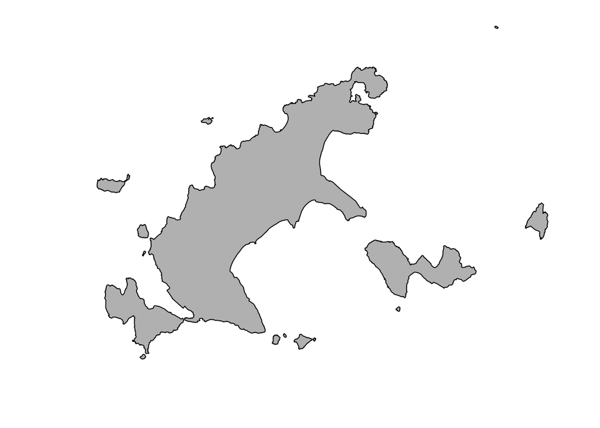

```r
con_dao %>%
  st_geometry() %>%
  plot(col = "grey")
```

Let’s add the polygon of Côn Đảo to the GADM data:

```r
vn2 %<>%
  filter(province == "Bà Rịa - Vũng Tàu") %>%
  head(1) %>%
  mutate(district = "Côn Đảo") %>%
  st_set_geometry(con_dao) %>%
  rbind(vn2)
```

## Adding the census 2019 data

For some reason the province of `Vĩnh Long` is missing… We add information form [Wikipedia](https://en.wikipedia.org/wiki/Vĩnh_Long_Province#Administrative_divisions):

```r
census <- census_path %>%
  readRDS() %>%
  group_by(province, district) %>%
  summarise(n = sum(n)) %>%
  ungroup() %>%
  mutate(province = str_squish(province) %>%
                    str_remove_all("Thành phố |Tỉnh ") %>%
                    str_replace("Đăk Lăk"             , "Đắk Lắk") %>%
                    str_replace("Đăk Nông"            , "Đắk Nông") %>%
                    str_replace("Khánh Hoà"           , "Khánh Hòa") %>%
                    str_replace("Thanh Hoá"           , "Thanh Hóa"),
         district = str_squish(district) %>%
                    str_replace("Thành phố Cao Lãnh"  , "Cao Lãnh (Thành phố)") %>%
                    str_replace("Thị xã Hồng Ngự"     , "Hồng Ngự (Thị xã)") %>%
                    str_replace("Thị xã Kỳ Anh"       , "Kỳ Anh (Thị xã)") %>%
                    str_replace("Thị xã Long Mỹ"      , "Long Mỹ (Thị xã)") %>%
                    str_replace("Thị xã Cai Lậy"      , "Cai Lậy (Thị xã)") %>%
                    str_replace("Thị xã Duyên Hải"    , "Duyên Hải (Thị xã)") %>%
                    str_remove_all("Huyện |Huỵên |Quận |Thành phố |Thành Phô |Thành Phố |Thị xã |Thị Xã ") %>%
                    str_replace("Hoà Vang"            , "Hòa Vang") %>%
                    str_replace("Ứng Hoà"             , "Ứng Hòa") %>%
                    str_replace("Đồng Phù"            , "Đồng Phú") %>%
                    str_replace("Đắk Glong"           , "Đăk Glong") %>%
                    str_replace("Ia H’Drai"           , "Ia H' Drai") %>%
                    str_replace("ý Yên"               , "Ý Yên") %>%
                    str_replace("Bác ái"              , "Bác Ái") %>%
                    str_replace("Phan Rang- Tháp Chàm", "Phan Rang-Tháp Chàm") %>%
                    str_replace("Đông Hoà"            , "Đông Hòa") %>%
                    str_replace("Tuy Hòa"             , "Tuy Hoà") %>%
                    str_replace("Thiệu Hoá"           , "Thiệu Hóa")) %>%
  bind_rows(
    bind_cols(
      data.frame(province = rep("Vĩnh Long", 8)),
      tribble(
        ~district  ,     ~n,
        "Bình Tân" ,  93758, # 2009
        "Long Hồ"  , 160537, # 2018
        "Mang Thít", 103573, # 2018
        "Tam Bình" , 162191, # 2003
        "Trà Ôn"   , 149983, # 2003
        "Vũng Liêm", 176233, # 2003
        "Bình Minh",  95282, # 2003
        "Vĩnh Long", 200120  # 2018
      )
    ),
    tribble(
      ~province  , ~district     , ~n,
      "Điện Biên", "Mường Ảng"   ,  37077, # 2006
      "Hải Phòng", "Bạch Long Vĩ",    912, # 2018
      "Phú Thọ"  , "Thanh Sơn"   , 187700, # 2003
      "Quảng Trị", "Cồn Cỏ"      ,    400  # 2003
    )
  )
```

```r
identical(sort(unique(census$province)), sort(unique(vn2$province)))
```

```
## [1] TRUE
```

```r
anti_join(census, vn2, c("province", "district"))
```

```
## # A tibble: 0 x 3
## # … with 3 variables: province <chr>, district <chr>, n <dbl>
```

```r
anti_join(vn2, census, c("province", "district"))
```

```
## Simple feature collection with 0 features and 2 fields
## bbox:           xmin: NA ymin: NA xmax: NA ymax: NA
## CRS:            EPSG:4326
## [1] province district geometry
## <0 rows> (or 0-length row.names)
```

```r
vn2 %<>% left_join(census, c("province", "district"))
```

```r
vn2 %>%
  st_drop_geometry() %>%
  group_by(province, district) %>%
  tally() %>%
  filter(n > 1)
```

```
## # A tibble: 0 x 3
## # Groups:   province [0]
## # … with 3 variables: province <chr>, district <chr>, n <int>
```

## Merging some districts

The colocation data use the [Bing](https://www.bing.com/maps) polygons, which do not seem to be very much up to date. In order to adjust for that, we need to merge the following districts in the GADM data:

- Hà Tĩnh: merge Kỳ Anh (Thị xã) into Kỳ Anh that split in 2015
- Hậu Giang: merge Long Mỹ (Thị xã) into Long Mỹ that split in 2015
- Tiền Giang: merge Cai Lậy (Thị xã) into Cai Lậy that split in 2013
- Trà Vinh: merge Duyên Hải (Thị xã) into Duyên Hải that split in 2015
- Bình Dương: merge Bắc Tân Uyên into Tân Uyên that split in 2013
- Bình Dương: merge Bàu Bàng into Bến Cát that split in 2013
- Hà Nội: merge Bắc Từ Liêm and Nam Từ Liêm into Từ Liêm that split in 2013
- Long An: merge Kiến Tường into Mộc Hóa that split in 2013
- Nghệ An: merge Hoàng Mai into Quỳnh Lưu that split in 2013
- Quảng Bình: merge Ba Đồn into Quảng Trạch that split in 2013

Furthermore, some of the districts need to be split in two, with each part merged to a different district. That’s the case for these 3 districts:

- Điện Biên: split Nậm Pồ into 2 parts and merge them with Mường Chà and Mường Nhé (2012)
- Lai Châu: split Nậm Nhùn into 2 parts and merge them with Mường Tè and Sìn Hồ (2012)
- Tuyên Quang: split Lâm Bình into 2 parts and merge them with Nà Hang and Chiêm Hóa (2011)

As illustrated below:

```r
plot_districts <- function(d1, d2, d3) {
  tmp <- vn2 %>%
    filter(district %in% c(d1, d2, d3)) %>%
    st_geometry()

  plot(tmp)
  plot(worldpop, add = TRUE, main = NA)
  plot(tmp, add = TRUE, col = adjustcolor("green", .2))

  vn2 %>%
    filter(district == d1) %>%
    st_geometry() %>%
    plot(add = TRUE, col = adjustcolor("red", .2))

  vn2_old %>%
    filter(district %in% c(d2, d3)) %>%
    st_geometry() %>%
    plot(add = TRUE, border = "blue", lwd = 2)
}
```

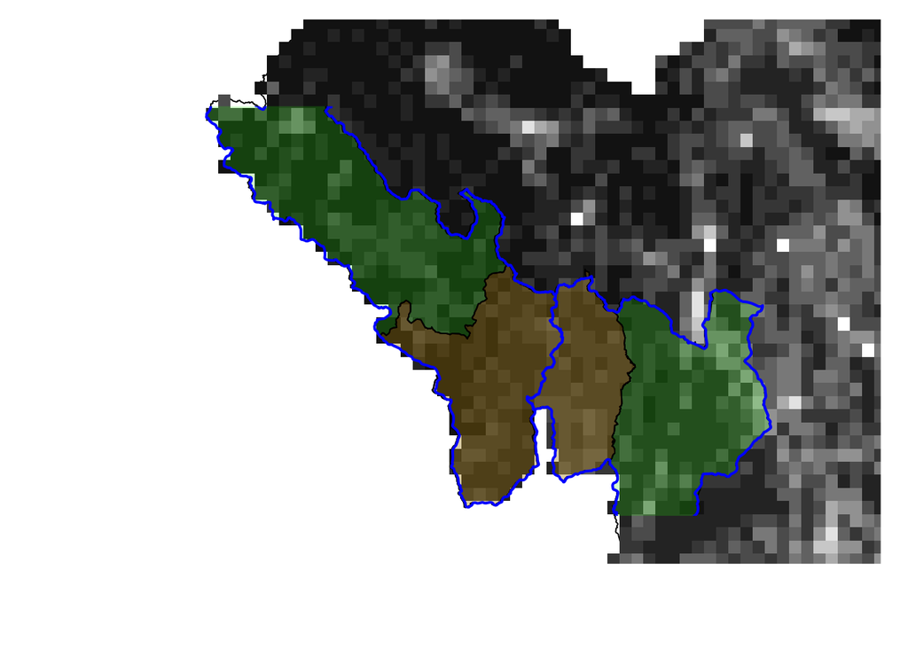

```r
plot_districts("Nậm Pồ"  , "Mường Chà", "Mường Nhé")
```

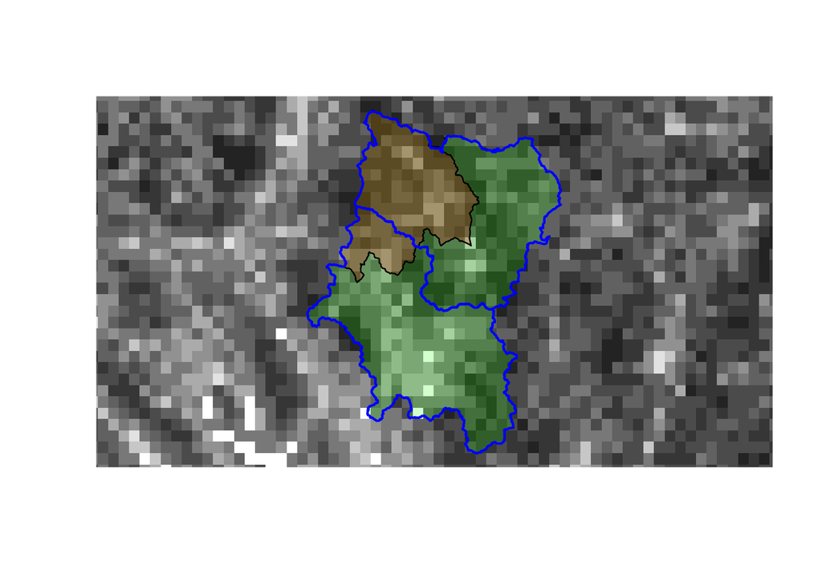

```r
plot_districts("Lâm Bình", "Nà Hang"  , "Chiêm Hóa")
```

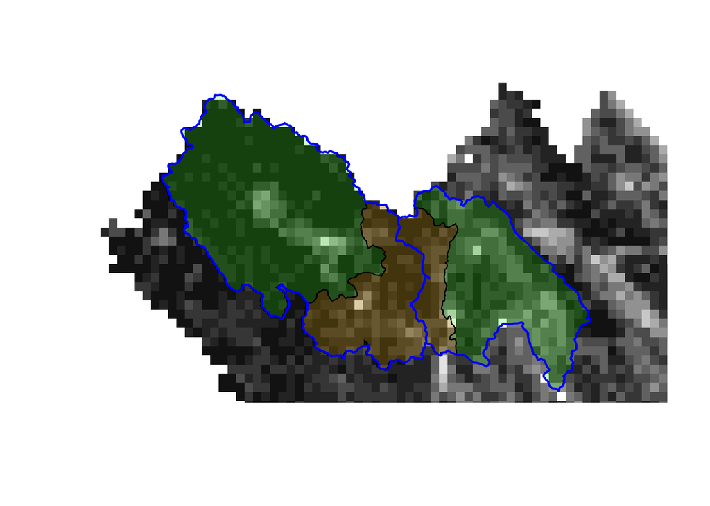

```r
plot_districts("Nậm Nhùn", "Mường Tè" , "Sìn Hồ")
```

The raster data shows the population density from [WorldPop](https://www.worldpop.org) that we’ll use to split the population of the red district into the 2 blue districts. Here are two functions to fix these 2 above-mentioned problems. Here is the first function:

```r
merge_districts <- function(vn, d1, d2, p) {
  dst <- c(d1, d2)

  tmp <- vn %>%
    filter(district %in% dst, province == p) %>%
    mutate(n = sum(n))

  tmp %<>%
    filter(district %in% d1) %>%
    st_set_geometry(st_union(tmp))

  vn %>%
    filter(! (district %in% dst & province == p)) %>%
    rbind(tmp) %>%
    arrange(province, district)
}
```

The second function needs this function:

```r
proportion <- function(to_cut, one_district, new_vn = vn2, old_vn = vn2_old, rstr = worldpop) {
  to_cut <- filter(new_vn, district == to_cut)
  one_part <- st_intersection(to_cut, filter(old_vn, district == one_district))

  wp0 <- rstr %>%
    st_crop(to_cut) %>%
    st_as_stars() %>%
    unlist() %>%
    sum(na.rm = TRUE)

  rstr %>%
    st_crop(one_part) %>%
    st_as_stars() %>%
    unlist() %>%
    sum(na.rm = TRUE) %>%
    divide_by(wp0)
}
```

Let’s try it:

```r
proportion("Nậm Nhùn", "Mường Tè" , vn2, vn2_old, worldpop)
```

```
## [1] 0.6717576
```

```r
proportion("Nậm Pồ"  , "Mường Chà", vn2, vn2_old, worldpop)
```

```
## [1] 0.4612189
```

```r
proportion("Lâm Bình", "Nà Hang"  , vn2, vn2_old, worldpop)
```

```
## [1] 0.7201902
```

And here is the second function we needed:

```r
merge_back_districts <- function(c2, d1, d2, d3, c1 = vn2_old, rstr = worldpop) {
  dsts <- c(d1, d2, d3)

  tmp <- c2 %>%
    filter(district %in% dsts) %$%
    setNames(n, district)

  half1 <- round(proportion(d1, d2, c2, c1, rstr) * tmp[d1])

  half2 <- tmp[d1] - half1
  tmp[d2] <- tmp[d2] + half1
  tmp[d3] <- tmp[d3] + half2
  tmp <- tmp[dsts[-1]]

  c1 %>%
    filter(district %in% dsts[-1]) %>%
    mutate(n = tmp) %>%
    select(everything(), geometry) %>%
    rbind(filter(c2, ! district %in% dsts)) %>%
    arrange(province, district)
}
```

Let’s now call these 2 functions to do the mergings:

```r
vn2 %<>%
  merge_districts("Kỳ Anh"     , "Kỳ Anh (Thị xã)"   , "Hà Tĩnh") %>%
  merge_districts("Long Mỹ"    , "Long Mỹ (Thị xã)"  , "Hậu Giang") %>%
  merge_districts("Cai Lậy"    , "Cai Lậy (Thị xã)"  , "Tiền Giang") %>%
  merge_districts("Duyên Hải"  , "Duyên Hải (Thị xã)", "Trà Vinh") %>%
  merge_districts("Tân Uyên"   , "Bắc Tân Uyên"      , "Bình Dương") %>%
  merge_districts("Bến Cát"    , "Bàu Bàng"          , "Bình Dương") %>%
  merge_districts("Bắc Từ Liêm", "Nam Từ Liêm"       , "Hà Nội") %>% # then rename to Từ Liêm
  merge_districts("Mộc Hóa"    , "Kiến Tường"        , "Long An") %>%
  merge_districts("Quỳnh Lưu"  , "Hoàng Mai"         , "Nghệ An") %>%
  merge_districts("Quảng Trạch", "Ba Đồn"            , "Quảng Bình") %>%
  merge_back_districts("Nậm Pồ"  , "Mường Chà", "Mường Nhé") %>%
  merge_back_districts("Nậm Nhùn", "Mường Tè" , "Sìn Hồ") %>%
  merge_back_districts("Lâm Bình", "Nà Hang"  , "Chiêm Hóa") %>%
  mutate(district = str_replace(district, "Bắc Từ Liêm", "Từ Liêm")) # here the renaming
```

Let’s calculate the areas:

```r
vn2 %<>%
  mutate(area = vn2 %>%
           st_geometry() %>%
           st_area()) %>%
  select(everything(), geometry)
```

## Visualizations

### Population sizes

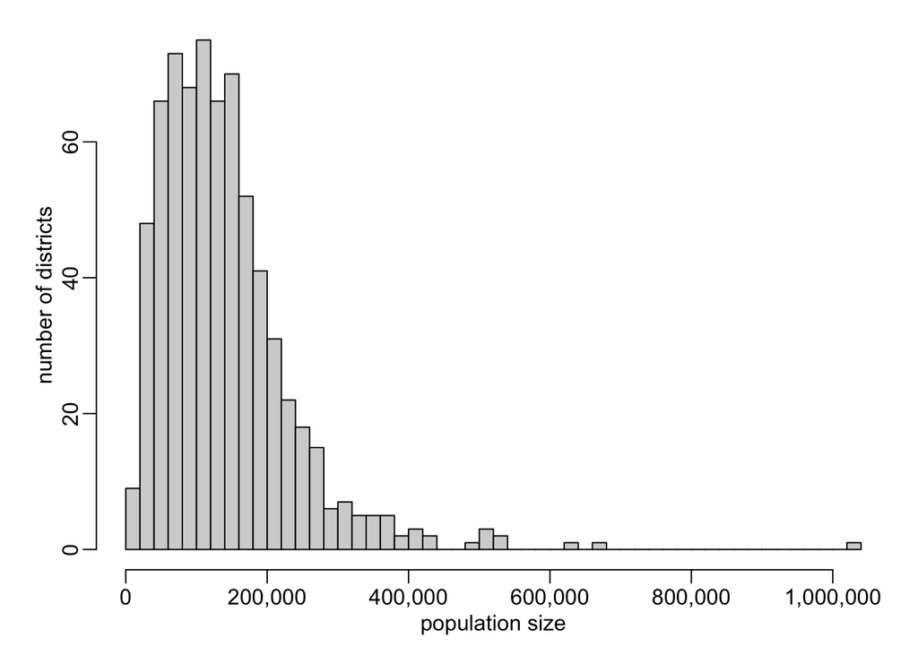

```r
hist2(vn2$n, n = 50, xlab = "population size", ylab = "number of districts", axes = FALSE)
axis(1, seq(0, 1e6, 2e5), format(seq(0, 10, 2) * 1e5, big.mark = ",", scientific = FALSE, trim = TRUE))
axis(2)
```

```r
cb <- RColorBrewer::brewer.pal(9, "YlOrBr")
color_generator <- colorRampPalette(cb)
pal <- color_generator(10)
```

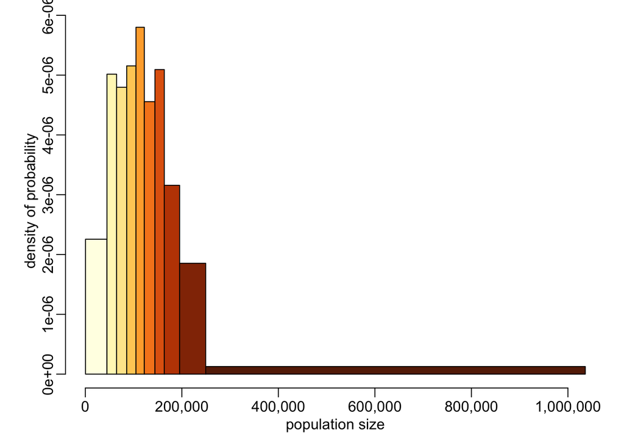

```r
hist2(vn2$n, quantile(vn2$n, seq(0, 1, le = 11)), col = pal, axes = FALSE,
      xlab = "population size", ylab = "density of probability")
axis(1, seq(0, 1e6, 2e5), format(seq(0, 10, 2) * 1e5, big.mark = ",", scientific = FALSE, trim = TRUE))
axis(2)
```

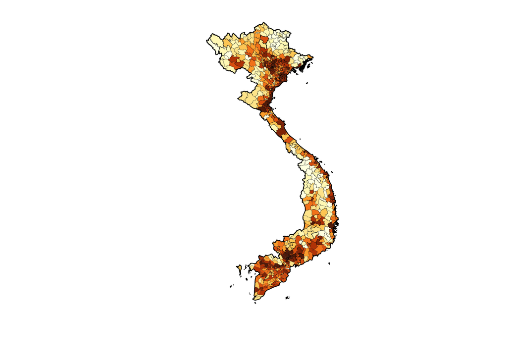

```r
vn2 %>%
  st_geometry() %>%
  plot(lwd = .1, col = pal[cut(vn2$n, quantile(vn2$n, seq(0, 1, le = 11)))], main = NA)

vn0 %>%
  st_geometry() %>%
  plot(add = TRUE)
```

```r
mean(vn2$n)
```

```
## [1] 139978.6
```

```r
median(vn2$n)
```

```
## [1] 122217
```

### Areas

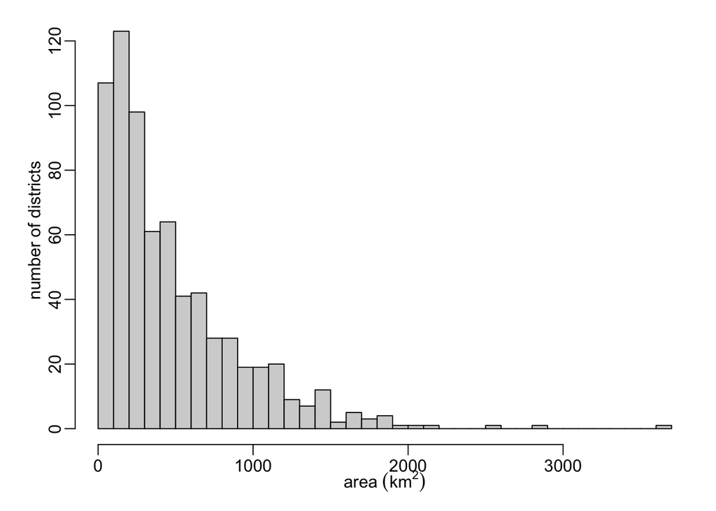

```r
hist2(vn2$area / 1e6, n = 50,
      xlab = expression(paste("area ", (km^2))), ylab = "number of districts")
```

```r
mean(as.numeric(vn2$area / 1e6))
```

```
## [1] 471.8696
```

```r
median(as.numeric(vn2$area / 1e6))
```

```
## [1] 339.3427
```

### Densities

```r
(quants <- quantile(as.numeric(1e6 * vn2$n / vn2$area), c(.025, .25, .5, .75, .975)))
```

```
##        2.5%         25%         50%         75%       97.5%
##    34.62209   115.50101   397.09968  1019.86255 20341.46013
```

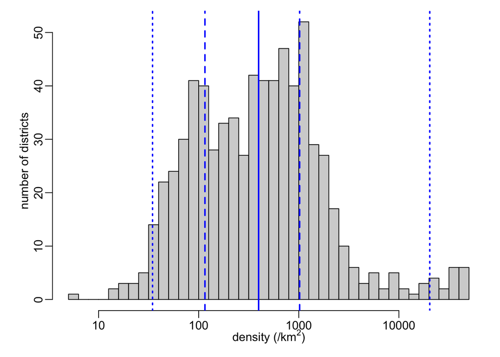

```r
hist2(log10(as.numeric(1e6 * vn2$n / vn2$area)), n = 50, axes = FALSE,
      xlab = expression(paste("density (/", km^2, ")")), ylab = "number of districts")
axis(1, 1:4, c("10", "100", "1000", "10000"))
axis(2)
abline(v = log10(quants), lty = c(3, 2, 1, 2, 3), col = "blue", lwd = 2)
```

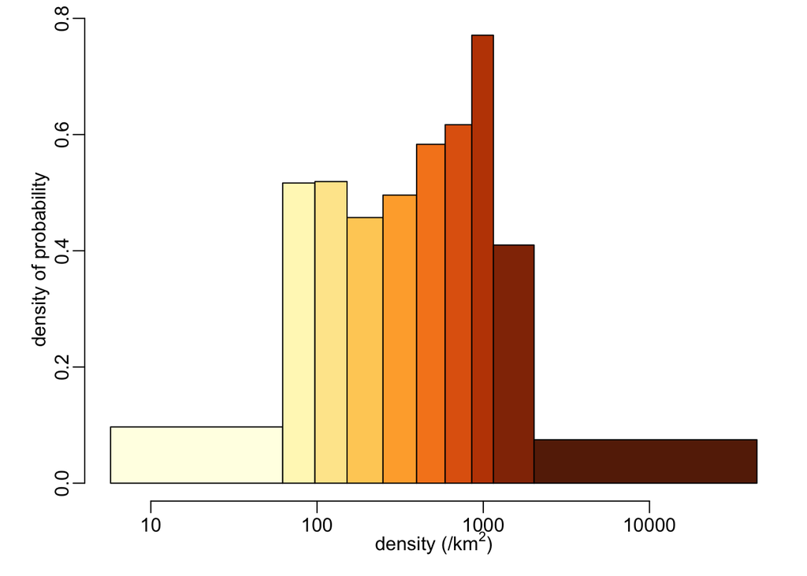

```r
xs <- log10(as.numeric(1e6 * vn2$n / vn2$area))
hist2(xs, quantile(xs, seq(0, 1, le = 11)), col = pal, axes = FALSE,
      xlab = expression(paste("density (/", km^2, ")")), ylab = "density of probability")
axis(1, 1:4, c("10", "100", "1000", "10000"))
axis(2)
```

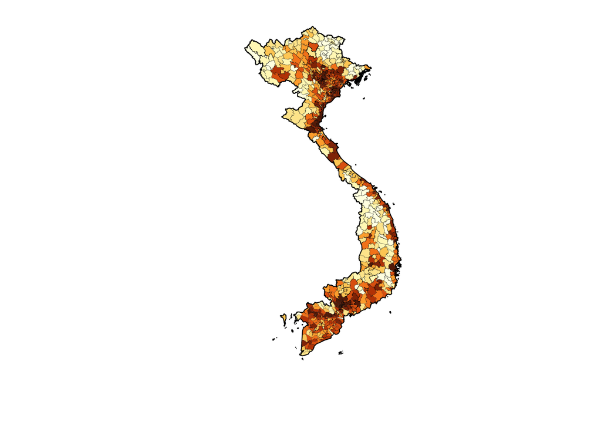

```r
vn2 %>%
  transmute(dens = 1e6 * n / area) %>%
  st_geometry() %>%
  plot(lwd = .1, col = pal[cut(vn2$n, quantile(vn2$n, seq(0, 1, le = 11)))], main = NA)

vn0 %>%
  st_geometry() %>%
  plot(add = TRUE)
```

## Colocation data

The list of colocation data files:

```r
files <- dir(colocation_path)
```

There are 17 of them:

```r
length(files)
```

```
## [1] 17
```

Making names from files names:

```r
weeks <- str_remove_all(files, "^.*__|.csv")
```

Loading the colocation data into a list (one slot per week):

```r
colocation <- paste0(colocation_path, dir(colocation_path)) %>%
  map(readr::read_csv) %>%
  setNames(weeks)
```

The colocation data looks like this:

```r
head(colocation, 1)
```

```
## $`2020-03-03`
## # A tibble: 448,665 x 15
##    polygon1_id polygon1_name lon_1 lat_1 name_stack_1 fb_population_1
##          <dbl> <chr>         <dbl> <dbl> <chr>                  <dbl>
##  1      834298 Huyện Lý Sơn   109.  15.4 Quảng Ngãi …             156
##  2      834671 Huyện Đạ Tẻh   108.  11.6 Lâm Đồng Pr…             123
##  3      834269 Huyện Hương …  107.  16.4 Thừa Thiên …             850
##  4      834290 Huyện Hiệp Đ…  108.  15.5 Quảng Nam P…             206
##  5      834320 Thị Xã Bình …  107.  11.7 Bình Phước …             991
##  6      834672 Huyện Cát Ti…  107.  11.7 Lâm Đồng Pr…             109
##  7      834652 Huyện Tuy Ph…  109.  11.4 Bình Thuận …            1555
##  8      834798 Huyện Đan Ph…  106.  21.1 Hanoi City …            2640
##  9      834599 Huyện Đông H…  106.  20.5 Thái Bình P…            1819
## 10      834336 Huyện Vĩnh H…  106.  10.9 Long An Pro…             422
## # … with 448,655 more rows, and 9 more variables: polygon2_id <dbl>,
## #   polygon2_name <chr>, lon_2 <dbl>, lat_2 <dbl>, name_stack_2 <chr>,
## #   fb_population_2 <dbl>, link_value <dbl>, country <chr>, ds <date>
```

Interesting to see, by the way, the effect of the lockdown:

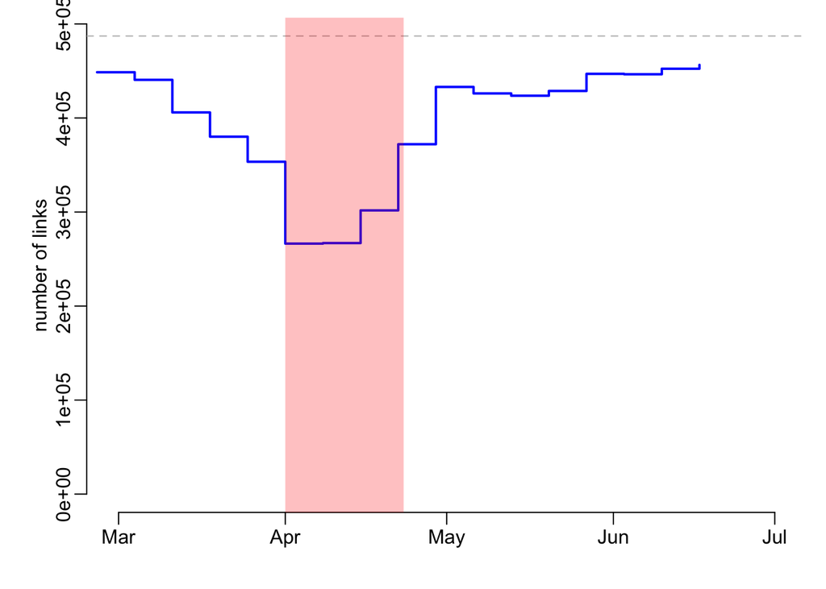

```r
nd <- nrow(vn2)
ld <- ymd(c(20200401, 20200423))
ys <- c(-1e5, 6e5)
xs <- ymd(names(colocation)) - 6
nb_links <- map_dbl(colocation, nrow)
xlim <- ymd(c("2020-02-29", "2020-07-01"))
plot(xs, nb_links, type = "s", xlab = NA, ylab = "number of links",
     xlim = xlim, ylim = c(0, nd^2), col = "blue", lwd = 2)
abline(h = nd^2, lty = 2, col = "grey")
polygon(c(ld, rev(ld)), rep(ys, each = 2), col = adjustcolor("red", .25), border = NA)
```

Let’s look at the sum of the probability per week:

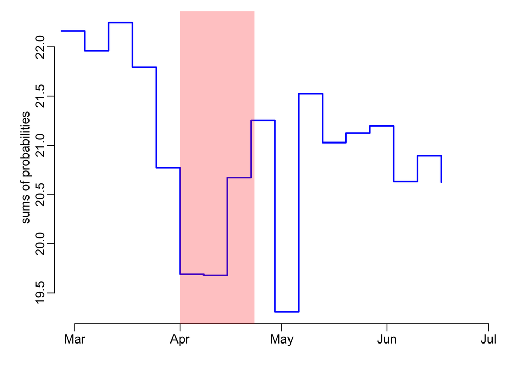

```r
link_val <- map(colocation, pull, link_value)
plot(xs, map_dbl(link_val, sum), type = "s", col = "blue", xlim = xlim,
     xlab = NA, ylab = "sums of probabilities", lwd = 2)
polygon(c(ld, rev(ld)), rep(ys, each = 2), col = adjustcolor("red", .25), border = NA)
```

The 10th week looks suspicious. There is no missing value and no zeros in the link variable:

```r
link_val %<>% unlist()
any(is.na(link_val))
```

```
## [1] FALSE
```

```r
range(link_val)
```

```
## [1] 2.716479e-12 2.276358e-01
```

## Getting rid off whatever is not linked to Vietnam

### The problem

Here we show what the problem is (i.e. some of the data are outside Vietnam). The following function plots the colocation data:

```r
plot_fb <- function(df, xlim, ylim, col) {
  plot(xlim, ylim, asp = 1, xlab = "longitude", ylab = "latitude", type = "n")
  maps::map(col = "grey", fill = TRUE, add = TRUE)
  points(df[[1]], df[[2]], pch = ".", col = col)
  axis(1)
  axis(2)
  box(bty = "o")
}
```

Let’s consider one week:

```r
june23 <- colocation$`2020-06-23`
```

The locations in this week are within these boundaries:

```r
(xlim <- range(range(june23$lon_1), range(june23$lon_2)))
```

```
## [1] 101.5709 109.3583
```

```r
(ylim <- range(range(june23$lat_1), range(june23$lat_2)))
```

```
## [1]  8.668113 23.237631
```

Let’s plot the polygon 1:

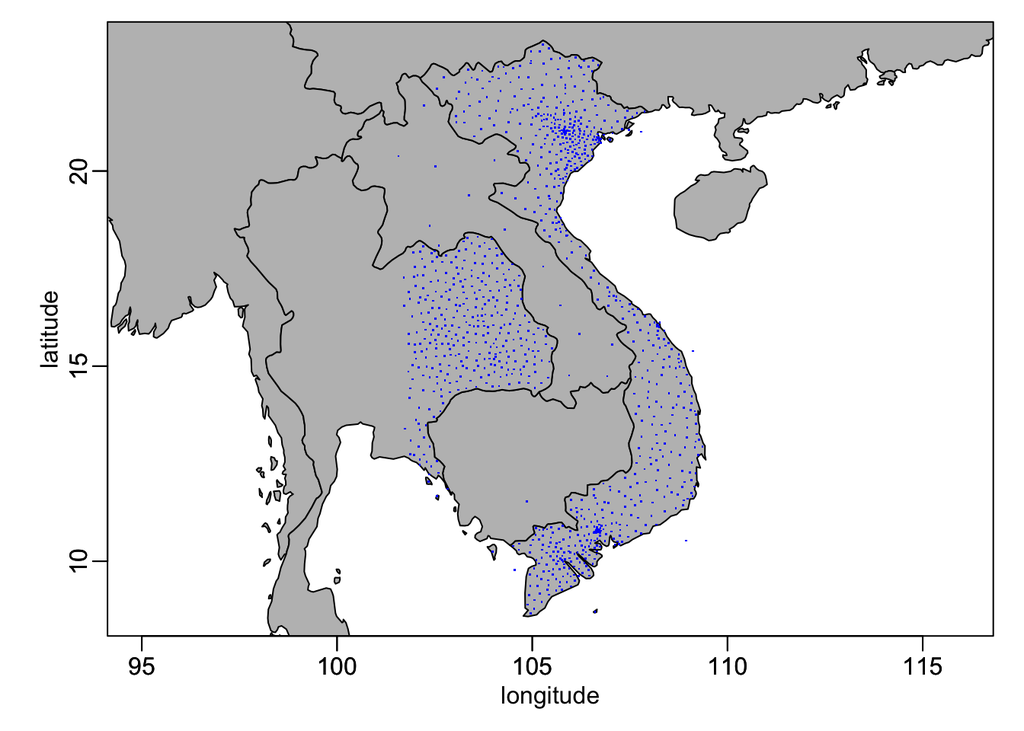

```r
june23 %>%
  select(lon_1, lat_1) %>%
  distinct() %>%
  plot_fb(xlim, ylim, "blue")
```

And the polygon 2:

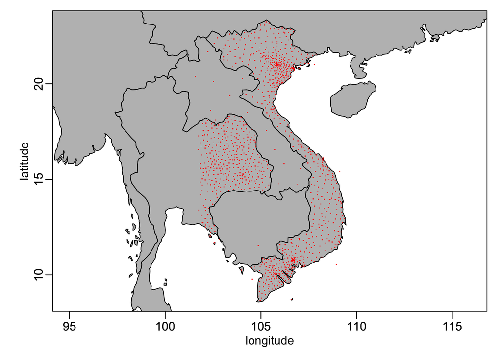

```r
june23 %>%
  select(lon_2, lat_2) %>%
  distinct() %>%
  plot_fb(xlim, ylim, "red")
```

### The solution

In the following function, `df` is a data frame with the same column names as a “colocation map” data frame. `pl` is an `sf` non-projected polygon. `type` is either `1` or `2`.

```r
pts_in_pol <- function(type, df, pl, project = FALSE) {
  # assumes that sf is not projected.
  # 4326: non-projected
  # 3857: pseudo-Mercator (e.g. Google Maps)
  df %<>% st_as_sf(coords = paste0(c("lon_", "lat_"), type), crs = 4326)
  if (project) {
    df %<>% st_transform(3857)
    pl %<>% st_transform(3857)
  }
  df %>%
    st_intersects(pl) %>%
    map_int(length)
}
```

The function returns a vector of length equal to the number of rows of `df` with `1` if the points is inside the polygon `pl` and `0` otherwise. Let’s try it:

```r
tmp <- pts_in_pol(1, june23, vn0)
```

```
## although coordinates are longitude/latitude, st_intersects assumes that they are planar
## although coordinates are longitude/latitude, st_intersects assumes that they are planar
```

It takes 3.5’ and it’s about 3 times slower if we project the points and polygon. The arguments of the following function are the same as the previous one. It uses the previous one to delete the records from `df` that have start and end coordinates that are outside `pl`:

```r
rcd_in_pol <- function(df, pl, project = FALSE) {
  require(magrittr)
  1:2 %>%
    parallel::mclapply(pts_in_pol, df, pl, project, mc.cores = 2) %>%
    as.data.frame() %>%
    rowSums() %>%
    is_greater_than(0) %>%
    magrittr::extract(df, ., ) # there is an extract() function in tidyr too
}
```

Let’s try it:

```r
june23 %<>% rcd_in_pol(vn0)
```

```r
colocation %<>% map(rcd_in_pol, vn0)
```

## Working out a district ID common to GADM + census and colocation data

The list of district in the colocation data:

```r
col_names <- c("polygon_id", "polygon_name", "lon", "lat", "name_stack")

districts1 <- map_dfr(colocation, select, polygon1_id, polygon1_name, lon_1, lat_1, name_stack_1) %>%
  setNames(col_names)

districts2 <- map_dfr(colocation, select, polygon2_id, polygon2_name, lon_2, lat_2, name_stack_2) %>%
  setNames(col_names)

districts <- bind_rows(districts1, districts2) %>%
  distinct()
```

This is what it looks like:

```r
districts
```

```
## # A tibble: 693 x 5
##    polygon_id polygon_name       lon   lat name_stack
##         <dbl> <chr>            <dbl> <dbl> <chr>
##  1     834298 Huyện Lý Sơn      109.  15.4 Quảng Ngãi Province // Huyện Lý Sơn
##  2     834671 Huyện Đạ Tẻh      108.  11.6 Lâm Đồng Province // Huyện Đạ Tẻh
##  3     834269 Huyện Hương Trà   107.  16.4 Thừa Thiên Huế Province // Huyện Hươ…
##  4     834290 Huyện Hiệp Đức    108.  15.5 Quảng Nam Province // Huyện Hiệp Đức
##  5     834320 Thị Xã Bình Long  107.  11.7 Bình Phước Province // Thị Xã Bình L…
##  6     834672 Huyện Cát Tiên    107.  11.7 Lâm Đồng Province // Huyện Cát Tiên
##  7     834652 Huyện Tuy Phong   109.  11.4 Bình Thuận Province // Huyện Tuy Pho…
##  8     834798 Huyện Đan Phượng  106.  21.1 Hanoi City // Huyện Đan Phượng
##  9     834599 Huyện Đông Hưng   106.  20.5 Thái Bình Province // Huyện Đông Hưng
## 10     834336 Huyện Vĩnh Hưng   106.  10.9 Long An Province // Huyện Vĩnh Hưng
## # … with 683 more rows
```

### Province name missing for some districts of Hanoi

In the colocation data, the `name_stack_*` variables contains the names of the province and the district separated by `//`. The problem is that there are a number of districts that do not have `//` in their `name_stack` variable and all of them seem to be in the province of Hanoi:

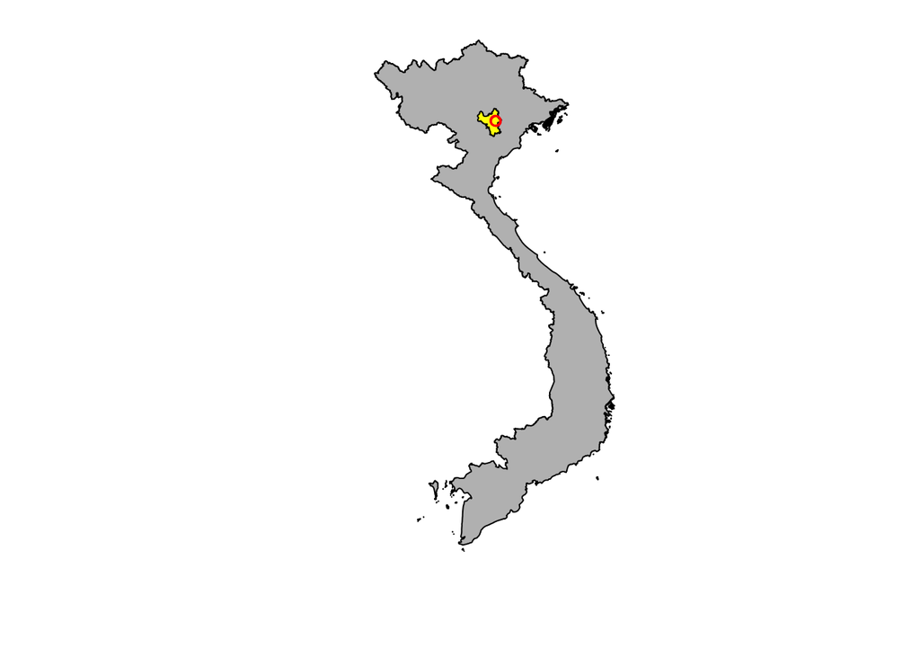

```r
plot(st_geometry(vn0), col = "grey")

vn1 %>%
  filter(NAME_1 == "Hà Nội") %>%
  st_geometry() %>%
  plot(add = TRUE, col = "yellow")

districts %>%
  filter(! grepl(" // ", name_stack)) %>%
  st_as_sf(coords = c("lon", "lat"), crs = 4326) %>%
  st_geometry() %>%
  plot(add = TRUE, col = "red")
```

### Separating province name from district name in the colocation data

Plus a number of names fixes:

```r
districts %<>%
  separate(name_stack, c("province", "district"), " // ") %>%
  mutate(indicate = is.na(district),
         district = ifelse(indicate, province, district),
         province = ifelse(indicate, "Hanoi City", province) %>%
           str_squish() %>%
           str_remove(" Province| City") %>%
           str_replace("-", " - ") %>%
           str_replace("Da Nang"     , "Đà Nẵng") %>%
           str_replace("Hanoi"       , "Hà Nội") %>%
           str_replace("Hai Phong"   , "Hải Phòng") %>%
           str_replace("Ho Chi Minh" , "Hồ Chí Minh") %>%
           str_replace("Hòa Bình"    , "Hoà Bình"),
         polygon_name = str_squish(polygon_name) %>%
           str_replace("Thành Phố Cao Lãnh", "Cao Lãnh (Thành phố)") %>%
           str_replace("Thị Xã Hồng Ngự", "Hồng Ngự (Thị xã)") %>%
           str_remove("Huyện |Thành phố |Thị xã |Quận |Thành Phố |Thị Xã ") %>%
           str_replace("Quy Nhơn"    , "Qui Nhơn") %>%
           str_replace("Đảo Phú Quý" , "Phú Quí") %>%
           str_replace("Bình Thủy"   , "Bình Thuỷ") %>%
           str_replace("Hòa An"      , "Hoà An") %>%
           str_replace("Phục Hòa"    , "Phục Hoà") %>%
           str_replace("Thái Hòa"    , "Thái Hoà") %>%
           str_replace("Hạ Hòa"      , "Hạ Hoà") %>%
           str_replace("Phú Hòa"     , "Phú Hoà") %>%
           str_replace("Tây Hòa"     , "Tây Hoà") %>%
           str_replace("Tuy Hòa"     , "Tuy Hoà") %>%
           str_replace("Krông Ana"   , "Krông A Na") %>%
           str_replace("Krông A Na"  , "Krông A Na") %>% ##
           str_replace("Krông Păk"   , "Krông Pắc") %>%
           str_replace("Krông Pắc"   , "Krông Pắc") %>% ##
           str_replace("Đắk Glong"   , "Đăk Glong") %>%
           str_replace("Đắk Rlấp"    , "Đắk R'Lấp") %>%
           str_replace("A Yun Pa"    , "Ayun Pa") %>%
           str_replace("Từ Liêm"     , "Nam Từ Liêm") %>%
           str_replace("Kiến Thụy"   , "Kiến Thuỵ") %>%
           str_replace("Thủy Nguyên" , "Thuỷ Nguyên") %>%
           str_replace("Vị Thủy"     , "Vị Thuỷ") %>%
           str_replace("Bác Ai"      , "Bác Ái") %>%
           str_replace("Thanh Thủy"  , "Thanh Thuỷ") %>%
           str_replace("Yên Hưng"    , "Quảng Yên") %>%
           str_replace("Na Hang"     , "Nà Hang") %>%
           str_replace("Mù Cang Chải", "Mù Căng Chải") %>%
           str_replace("M`Đrắk"      , "M'Đrắk") %>%
           str_replace("Cư M`Gar"    , "Cư M'gar") %>%
           str_replace("Ea H`Leo"    , "Ea H'leo") %>%
           str_replace("Nam Từ Liêm" , "Từ Liêm") %>%
           str_replace("Buôn Hồ"     , "Buôn Hồ"),
         polygon_name = ifelse(province == "Bạc Liêu" & polygon_name == "Hòa Bình",
                               "Hoà Bình", polygon_name)) %>%
  select(-indicate, -district) %>%
  rename(district = polygon_name)
```

```
## Warning: Expected 2 pieces. Missing pieces filled with `NA` in 4 rows [82, 210,
## 309, 593].
```

The warnings are produced when the provinces names are missing for some of the districts of Hanoi. Separating the districts names per province for both sources:

```r
anti_join(districts, vn2, c("province", "district"))
```

```
## # A tibble: 0 x 5
## # … with 5 variables: polygon_id <dbl>, district <chr>, lon <dbl>, lat <dbl>,
## #   province <chr>
```

```r
anti_join(vn2, districts, c("province", "district"))
```

```
## Simple feature collection with 5 features and 4 fields
## geometry type:  MULTIPOLYGON
## dimension:      XY
## bbox:           xmin: 104.636 ymin: 11.60531 xmax: 107.7464 ymax: 21.04582
## CRS:            +proj=longlat +datum=WGS84 +no_defs +ellps=WGS84 +towgs84=0,0,0
##     province     district     n             area                       geometry
## 1 Bình Phước    Phú Riềng 97931  667330016 [m^2] MULTIPOLYGON (((106.8315 11...
## 2  Hải Phòng Bạch Long Vĩ   912   15273999 [m^2] MULTIPOLYGON (((107.7457 20...
## 3    Kon Tum   Ia H' Drai  6638 1159609633 [m^2] MULTIPOLYGON (((107.4588 13...
## 4  Quảng Trị       Cồn Cỏ   400    2176718 [m^2] MULTIPOLYGON (((107.343 17....
## 5     Sơn La       Vân Hồ 61197  969335926 [m^2] MULTIPOLYGON (((105.0134 20...
```

Let’s map these districts that never have any data:

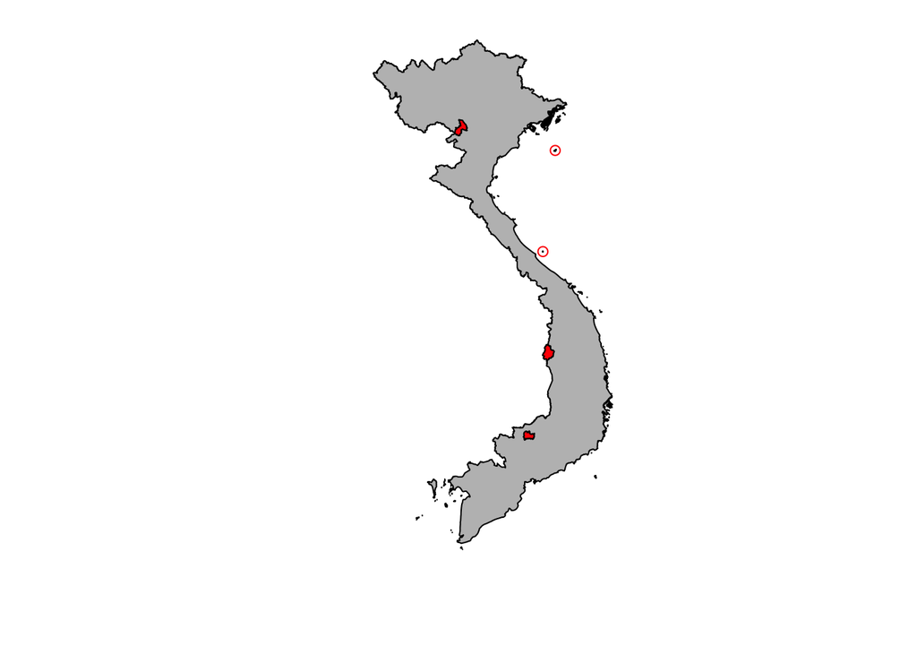

```r
vn0 %>%
  st_geometry() %>%
  plot(col = "grey")

tmp <- vn2 %>%
  mutate(pd = paste(province, district)) %>%
  filter(! pd %in% with(districts, paste(province, district)))

tmp %>%
  st_geometry() %>%
  plot(add = TRUE, col = "red")

tmp %>%
  st_centroid() %>%
  st_coordinates() %>%
  as_tibble() %>%
  filter(between(Y, 15, 20.5)) %>%
  st_as_sf(coords = c("X", "Y")) %>%
  plot(add = TRUE, col = "red")
```

Let’s add these 5 districts to `districts`:

```r
tmp <- vn2 %>%
  mutate(pd = paste(province, district)) %>%
  filter(! pd %in% with(districts, paste(province, district)))

districts <- tmp %>%
  st_centroid() %>%
  st_coordinates() %>%
  as_tibble() %>%
  transmute(lon = X, lat = Y) %>%
  bind_cols(tmp) %>%
  mutate(polygon_id = 850001:850005) %>%
  select(polygon_id, district, lon, lat, province) %>%
  bind_rows(districts)
```

This is what it looks like now:

```r
districts
```

```
## # A tibble: 698 x 5
##    polygon_id district       lon   lat province
##         <dbl> <chr>        <dbl> <dbl> <chr>
##  1     850001 Phú Riềng     107.  11.7 Bình Phước
##  2     850002 Bạch Long Vĩ  108.  20.1 Hải Phòng
##  3     850003 Ia H' Drai    108.  14.2 Kon Tum
##  4     850004 Cồn Cỏ        107.  17.2 Quảng Trị
##  5     850005 Vân Hồ        105.  20.8 Sơn La
##  6     834298 Lý Sơn        109.  15.4 Quảng Ngãi
##  7     834671 Đạ Tẻh        108.  11.6 Lâm Đồng
##  8     834269 Hương Trà     107.  16.4 Thừa Thiên Huế
##  9     834290 Hiệp Đức      108.  15.5 Quảng Nam
## 10     834320 Bình Long     107.  11.7 Bình Phước
## # … with 688 more rows
```

## Rearranging the colocation data into a matrix

Let’s generate a template with all the combinations of districts:

```r
template <- districts %>%
  arrange(polygon_id) %$%
  expand.grid(polygon_id, polygon_id) %>%
  as_tibble() %>%
  setNames(c("polygon1_id", "polygon2_id"))
```

The function that transform the colocation data into a matrix:

```r
to_matrix <- function(df, template) {
  dim_names <- sort(unique(template$polygon1_id))
  df %>%
    select(polygon1_id, polygon2_id, link_value) %>%
    left_join(template, ., c("polygon1_id", "polygon2_id")) %>%
    mutate(link_value = replace_na(link_value, 0)) %>%
    pull(link_value) %>%
    matrix(nrow(districts)) %>%
    `colnames<-`(dim_names) %>%
    `rownames<-`(dim_names)
}
```

Let’s do it for all the weeks and sum them:

```r
coloc_mat <- colocation %>%
  map(to_matrix, template) %>%
  reduce(`+`)
```

Let’s have a look at this matrix. Let’s first order the district from south to north and from west to east:

```r
hash <- setNames(seq_along(colnames(coloc_mat)),
                           colnames(coloc_mat))
ind <- districts %>%
  arrange(lat, lon) %>%
  pull(polygon_id) %>%
  as.character() %>%
  magrittr::extract(hash, .)

coloc_mat <- coloc_mat[ind, ind]
```

Let’s now plot the matrix:

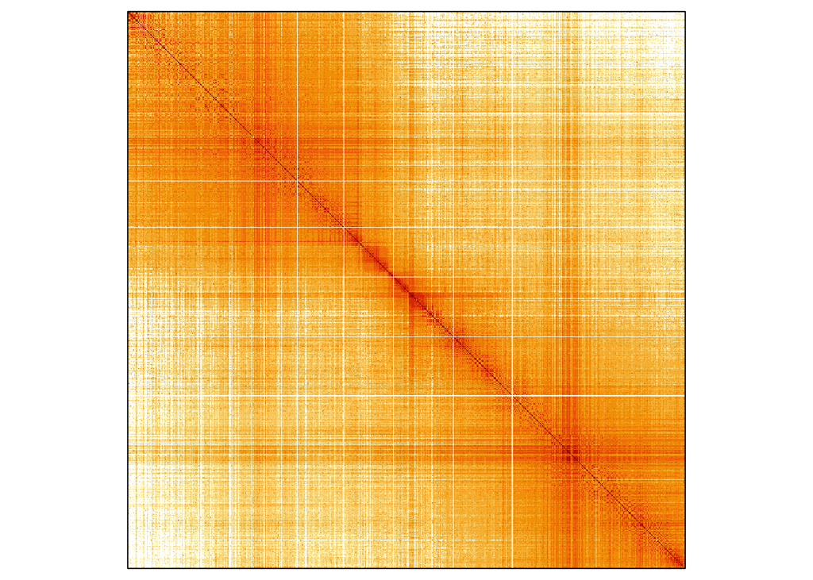

```r
opar <- par(pty = "s")
image(log10(apply(t(coloc_mat), 2, rev)), axes = FALSE)
par(opar)
box(bty = "o")
```

We can verify that the matrix is symmetric and that both Hanoi and Saigon are well connected to every where in the country. We can see also the district that are not connected at all.

### Subsetting according to coordinates

Let’s say we want to select all the provinces from the Northern EPI, the southernmost province of which is Nghệ An. Let’s retrieve the latitude of the centroids of all the provinces:

```r
tmp <- vn1 %>%
  st_centroid() %>%
  st_coordinates() %>%
  as_tibble() %>%
  pull(Y) %>%
  mutate(vn1, lat_cent = .) %>%
  select(NAME_1, lat_cent)
```

The province south of Nghệ An is Hà Tĩnh, the latitude of centroid of which is:

```r
threshold <- tmp %>%
  filter(NAME_1 == "Hà Tĩnh") %>%
  pull(lat_cent)
```

Now, we retrieve all the names of all the provinces that are north of this threshold:

```r
northernEPI <- tmp %>%
  filter(lat_cent > threshold) %>%
  pull(NAME_1)
```

Now, we retrieve the corresponding districts’ ID:

```r
sel <- districts %>%
  filter(province %in% northernEPI) %>%
  pull(polygon_id)
```

And now we can subset our matrix:

```r
sel <- colnames(coloc_mat) %in% sel
coloc_mat_northernEPI <- coloc_mat[sel, sel]
```

Which gives:

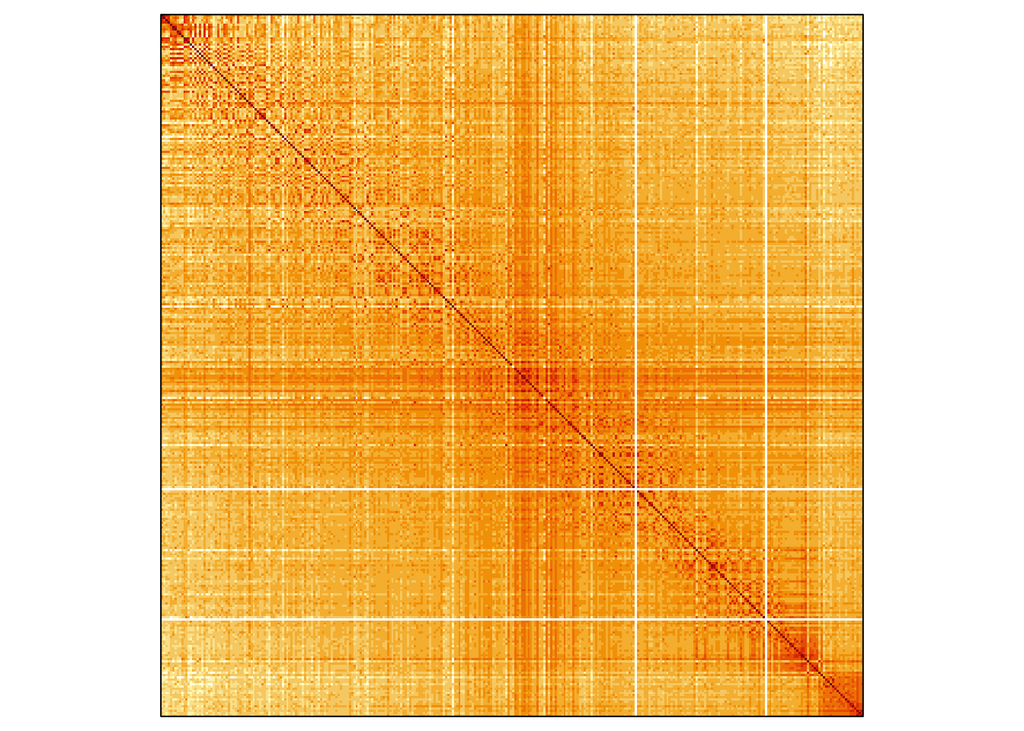

```r
opar <- par(pty = "s")
image(log10(apply(t(coloc_mat_northernEPI), 2, rev)), axes = FALSE)
par(opar)
box(bty = "o")
```